# Projet modèles statistiques ‘Diabetes_Dataset’

Yassmine TAI TAHIRI, Hadil CHTIOUI, Omar El Farouk CHTIOUI, Nada BOUSSETTA

Aperçu du jeu de données

Ce jeu de données comprend des informations sur la santé et les caractéristiques démographiques de 100 000 individus, dans le but de faciliter la recherche et la modélisation prédictive liées au diabète. Chaque ligne représente un individu unique, et le jeu de données comporte 16 colonnes avec des informations détaillées sur la santé et la démographie.

## Comment le jeu de données a-t-il été obtenu ?

Le jeu de données utilisé dans ce projet a été téléchargé depuis Kaggle, à partir de ce lien :

https://www.kaggle.com/datasets/priyamchoksi/100000-diabetes-clinical-dataset/data

## Description de la question

## Quels sont les facteurs les plus associés à la présence de diabète chez un individu ?

# Méthodologie

**Bibliothèques nécessaires**

Avant de commencer notre analyse, nous devons importer les bibliothèques nécessaires qui faciliteront le traitement des données, les visualisations et les calculs statistiques.

## Analyse globale

Nous allons maintenant procéder à une analyse globale de notre jeu de données pour mieux comprendre sa structure et son contenu.

**Lecture du fichier**

La première étape consiste à lire notre fichier Excel

**Dimensions du jeu de données**

Vérifions le nombre de lignes et de colonnes dans notre jeu de données.

```
## [1] 100000     16
```

```
##  [1] "year"                 "gender"               "age"
##  [4] "location"             "race:AfricanAmerican" "race:Asian"
##  [7] "race:Caucasian"       "race:Hispanic"        "race:Other"
## [10] "hypertension"         "heart_disease"        "smoking_history"
## [13] "bmi"                  "hbA1c_level"          "blood_glucose_level"
## [16] "diabetes"
```

**Résumé des données**

Tout d’abord, nous utilisons la fonction `summary()` pour obtenir un aperçu statistique global du jeu de données.

```
##       year         gender               age          location
##  Min.   :2015   Length:100000      Min.   : 0.08   Length:100000
##  1st Qu.:2019   Class :character   1st Qu.:24.00   Class :character
##  Median :2019   Mode  :character   Median :43.00   Mode  :character
##  Mean   :2018                      Mean   :41.89
##  3rd Qu.:2019                      3rd Qu.:60.00
##  Max.   :2022                      Max.   :80.00
##  race:AfricanAmerican   race:Asian     race:Caucasian   race:Hispanic
##  Min.   :0.0000       Min.   :0.0000   Min.   :0.0000   Min.   :0.0000
##  1st Qu.:0.0000       1st Qu.:0.0000   1st Qu.:0.0000   1st Qu.:0.0000
##  Median :0.0000       Median :0.0000   Median :0.0000   Median :0.0000
##  Mean   :0.2022       Mean   :0.2001   Mean   :0.1988   Mean   :0.1989
##  3rd Qu.:0.0000       3rd Qu.:0.0000   3rd Qu.:0.0000   3rd Qu.:0.0000
##  Max.   :1.0000       Max.   :1.0000   Max.   :1.0000   Max.   :1.0000
##    race:Other   hypertension     heart_disease     smoking_history
##  Min.   :0.0   Min.   :0.00000   Min.   :0.00000   Length:100000
##  1st Qu.:0.0   1st Qu.:0.00000   1st Qu.:0.00000   Class :character
##  Median :0.0   Median :0.00000   Median :0.00000   Mode  :character
##  Mean   :0.2   Mean   :0.07485   Mean   :0.03942
##  3rd Qu.:0.0   3rd Qu.:0.00000   3rd Qu.:0.00000
##  Max.   :1.0   Max.   :1.00000   Max.   :1.00000
##       bmi         hbA1c_level    blood_glucose_level    diabetes
##  Min.   :10.01   Min.   :3.500   Min.   : 80.0       Min.   :0.000
##  1st Qu.:23.63   1st Qu.:4.800   1st Qu.:100.0       1st Qu.:0.000
##  Median :27.32   Median :5.800   Median :140.0       Median :0.000
##  Mean   :27.32   Mean   :5.528   Mean   :138.1       Mean   :0.085
##  3rd Qu.:29.58   3rd Qu.:6.200   3rd Qu.:159.0       3rd Qu.:0.000
##  Max.   :95.69   Max.   :9.000   Max.   :300.0       Max.   :1.000
```

Cette fonction affiche des informations sur la longueur, la classe et le mode de chaque variable.

Ensuite, nous utilisons la fonction str() pour examiner la structure du jeu de données.

```
## spc_tbl_ [100,000 × 16] (S3: spec_tbl_df/tbl_df/tbl/data.frame)
##  $ year                : num [1:100000] 2020 2015 2015 2015 2016 ...
##  $ gender              : chr [1:100000] "Female" "Female" "Male" "Male" ...
##  $ age                 : num [1:100000] 32 29 18 41 52 66 49 15 51 42 ...
##  $ location            : chr [1:100000] "Alabama" "Alabama" "Alabama" "Alabama" ...
##  $ race:AfricanAmerican: num [1:100000] 0 0 0 0 1 0 0 0 1 0 ...
##  $ race:Asian          : num [1:100000] 0 1 0 0 0 0 0 0 0 0 ...
##  $ race:Caucasian      : num [1:100000] 0 0 0 1 0 1 1 0 0 1 ...
##  $ race:Hispanic       : num [1:100000] 0 0 0 0 0 0 0 0 0 0 ...
##  $ race:Other          : num [1:100000] 1 0 1 0 0 0 0 1 0 0 ...
##  $ hypertension        : num [1:100000] 0 0 0 0 0 0 0 0 0 0 ...
##  $ heart_disease       : num [1:100000] 0 0 0 0 0 0 0 0 0 0 ...
##  $ smoking_history     : chr [1:100000] "never" "never" "never" "never" ...
##  $ bmi                 : num [1:100000] 27.3 19.9 23.8 27.3 23.8 ...
##  $ hbA1c_level         : num [1:100000] 5 5 4.8 4 6.5 5.7 5.7 5 6 5.7 ...
##  $ blood_glucose_level : num [1:100000] 100 90 160 159 90 159 80 155 100 160 ...
##  $ diabetes            : num [1:100000] 0 0 0 0 0 0 0 0 0 0 ...
##  - attr(*, "spec")=
##   .. cols(
##   ..   year = col_double(),
##   ..   gender = col_character(),
##   ..   age = col_double(),
##   ..   location = col_character(),
##   ..   `race:AfricanAmerican` = col_double(),
##   ..   `race:Asian` = col_double(),
##   ..   `race:Caucasian` = col_double(),
##   ..   `race:Hispanic` = col_double(),
##   ..   `race:Other` = col_double(),
##   ..   hypertension = col_double(),
##   ..   heart_disease = col_double(),
##   ..   smoking_history = col_character(),
##   ..   bmi = col_double(),
##   ..   hbA1c_level = col_double(),
##   ..   blood_glucose_level = col_double(),
##   ..   diabetes = col_double()
##   .. )
##  - attr(*, "problems")=<externalptr>
```

Cela nous permet de vérifier les types de variables et leur contenu, ce qui est essentiel pour comprendre la structure des données avant d’effectuer des analyses plus avancées.

## Netoyage des données ‘Data Cleaning’

- Identifier les doublons dans le jeu de données

Nous commençons par vérifier s’il y a des lignes en double dans notre jeu de données.

```
## [1] 14
```

Nous les supprimons en utilisant l’indexation logique. Nous gardons uniquement les lignes uniques dans le jeu de données.

- Identifier les valeurs manquantes

Nous vérifions ensuite s’il y a des valeurs manquantes dans le jeu de données.

```
##                 year               gender                  age
##                    0                    0                    0
##             location race:AfricanAmerican           race:Asian
##                    0                    0                    0
##       race:Caucasian        race:Hispanic           race:Other
##                    0                    0                    0
##         hypertension        heart_disease      smoking_history
##                    0                    0                    0
##                  bmi          hbA1c_level  blood_glucose_level
##                    0                    0                    0
##             diabetes
##                    0
```

# Analyse

## Analyse de la colonnes diabetes

Nous allons examiner les différentes valeurs que peut prendre la colonne diabetes, ainsi que leur fréquence d’apparition :

```
##
##     0     1
## 91486  8500
```

Le tableau de fréquences montre que :

-La valeur 0 indique que la personne n’est pas diabétique.

-La valeur 1 indique que la personne est diabétique.

D’après les résultats, on observe que :

-91486 personnes ne sont pas diabétiques.

-8500 personnes sont diabétiques.

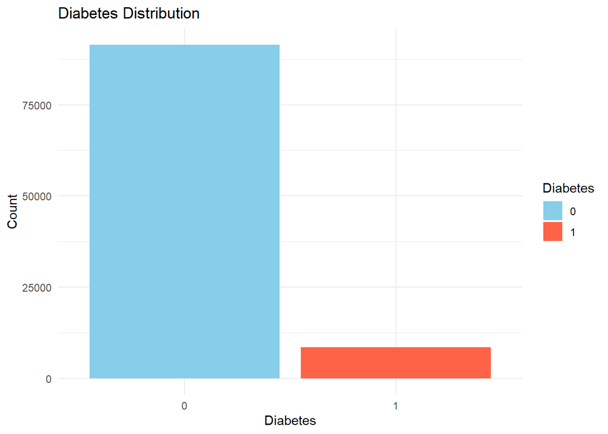

On peut clairement remarquer un déséquilibre dans les classes de notre jeu de données. Ce type de déséquilibre peut poser problème si l’on souhaite utiliser ces données pour entraîner un modèle de prédiction, car le modèle pourrait être biaisé en faveur de la classe majoritaire. Cependant, dans notre cas, l’objectif n’est pas la prédiction, donc ce déséquilibre ne représente pas une contrainte majeure pour notre analyse.

## Analyse des facteurs influençant le diabète

- Genre :

Nous commençons par analyser la colonne gender afin d’identifier les différentes valeurs qu’elle peut prendre et leur fréquence :

```
##
## Female   Male  Other
##  58546  41422     18
```

On observe que cette variable contient trois valeurs distinctes : **Male**, **Female** et **Other**. Toutefois, la catégorie Other représente une proportion très faible du jeu de données.

Pour mieux visualiser la relation entre le sexe et le statut diabétique, on utilise un graphique en barres :

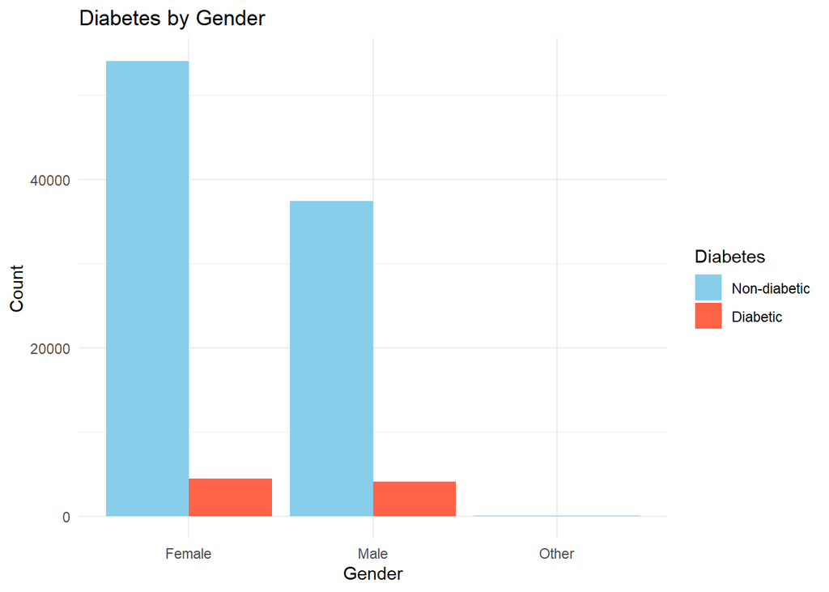

On décide également de supprimer les observations dont le sexe est “Other”, car elles sont peu représentatives par rapport aux autres catégories, et surtout parce qu’aucune de ces personnes n’est atteinte de diabète.

- Âge :

Nous poursuivons l’analyse avec l’âge. Commençons par calculer l’âge moyen de toutes les personnes dans le jeu de données :

```
## [1] 41.88815
```

Une autre analyse intéressante serait de comparer l’âge des personnes diabétiques et non diabétiques. Cela pourrait nous donner une idée de l’âge moyen des personnes atteintes de diabète par rapport aux autres.

| diabetes | mean_age |
| --- | --- |
| 0 | 40.11707 |
| 1 | 60.94659 |

Pour une meilleure compréhension visuelle, utilisons un boxplot :

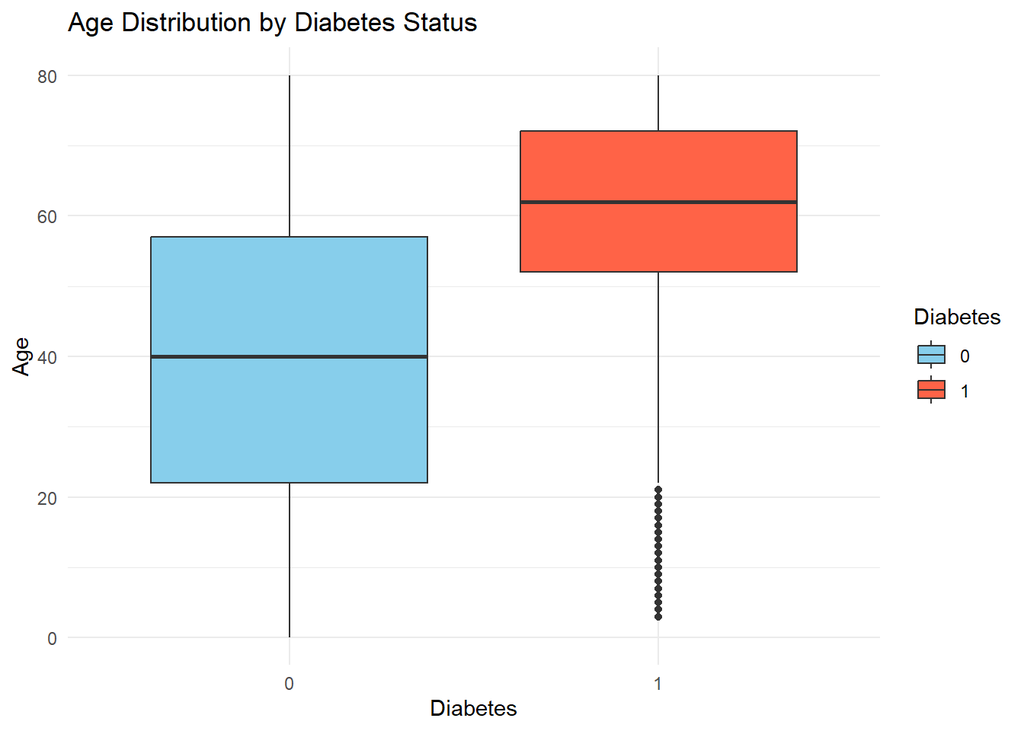

## Interprétation des résultats

Le boxplot montre que les personnes atteintes de diabète sont en moyenne plus âgées que celles qui ne le sont pas.

Cette tendance est cohérente avec ce que l’on sait médicalement : l’âge est un facteur de risque important dans l’apparition du diabète.

- Hypertension :

Nous analysons ici l’effet de l’hypertension sur la présence de diabète.

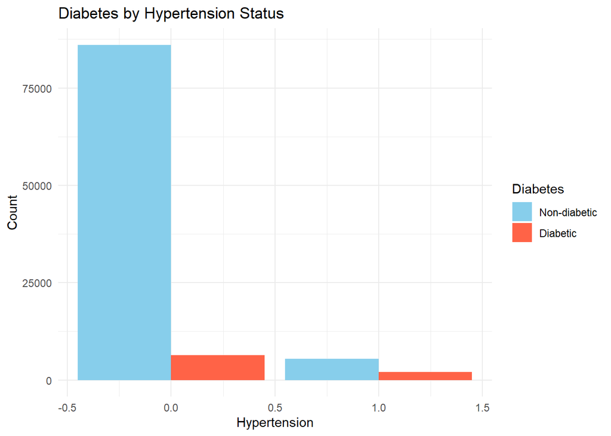

- Indice de Masse Corporelle (BMI) :

Nous examinons le lien entre l’IMC (BMI) et le diabète.

| diabetes | mean_bmi | sd_bmi |
| --- | --- | --- |
| 0 | 26.88700 | 6.373914 |
| 1 | 31.98838 | 7.558371 |

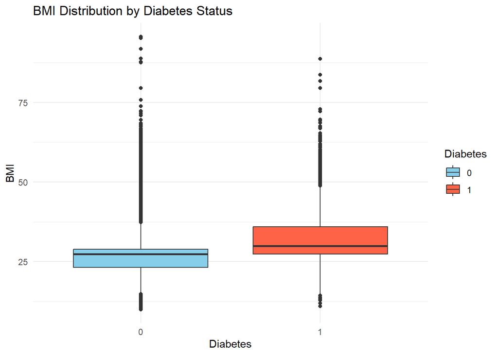

Le BMI moyen des diabétiques est plus élevé que celui des non-diabétiques, cela renforcera l’idée que l’obésité est un facteur de risque pour le diabète.

- HbA1c Level :

Nous comparons ici les niveaux de HbA1c entre les personnes diabétiques et non diabétiques.

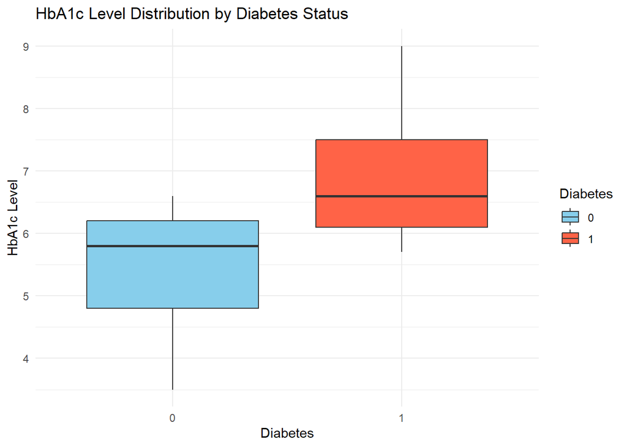

Cela permet de comparer les niveaux de HbA1c entre les personnes diabétiques et non diabétiques. On remarque que les personnes diabétiques présentent des valeurs plus élevées.

- Tabagisme (smoking_history) :

Les valeurs possibles :

```
##
##     current        ever      former       never     No Info not current
##        9286        4003        9352       35088       35800        6439
```

On remarque la présence d’une valeur “No Info”, qui ne permet pas de savoir si la personne a fumé ou non.

Ces observations sont donc exclues de l’analyse, car elles ne sont pas significatives.

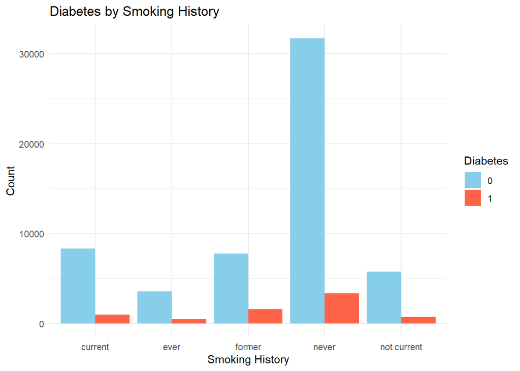

- Origine ethnique : African American :

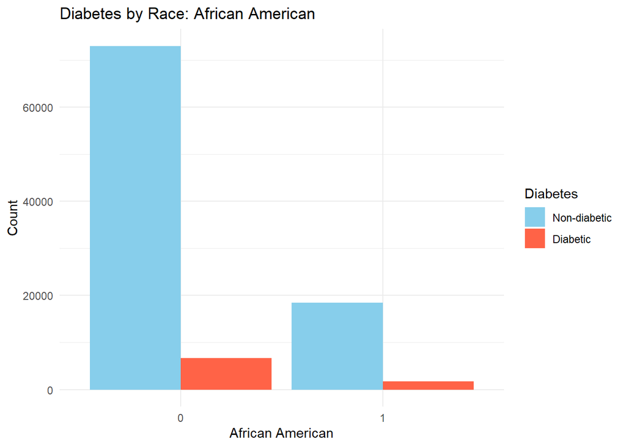

- Niveau de glucose sanguin (Blood Glucose) :

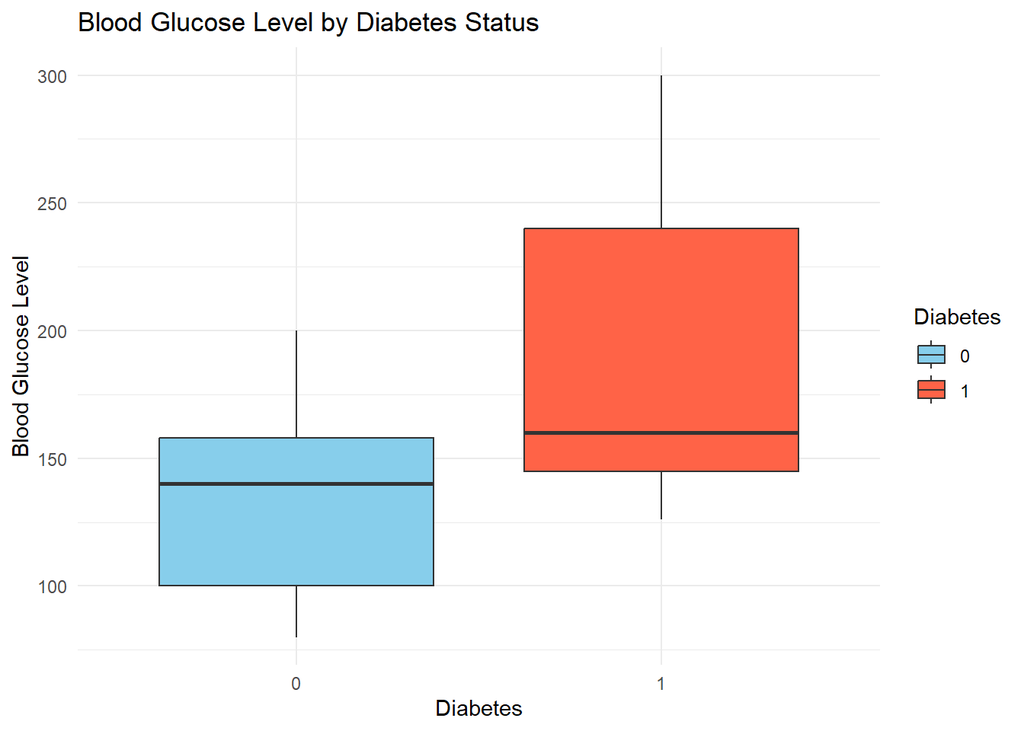

Comme attendu, les personnes diabétiques présentent en moyenne un niveau de glucose plus élevé, ce qui confirme que la glycémie est un indicateur essentiel du diabète.

- Maladie cardiaque (Heart disease) :

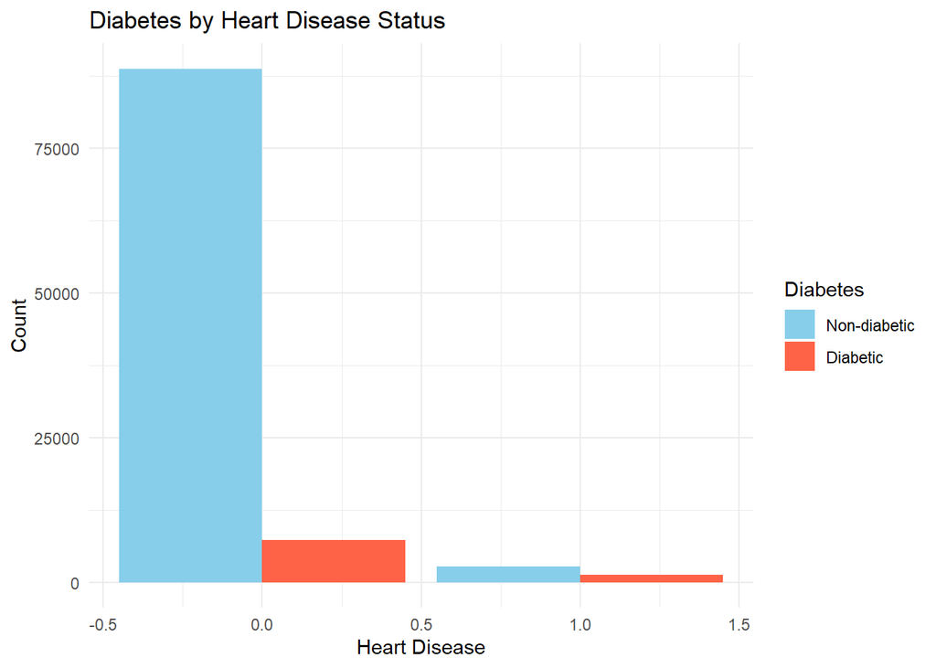

- Origine ethnique (Asian) :

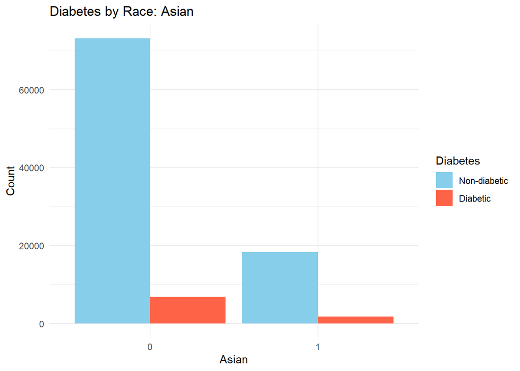

## Corrélation entre variables

Pour aller plus loin, analysons les corrélations entre les variables numériques pertinentes.

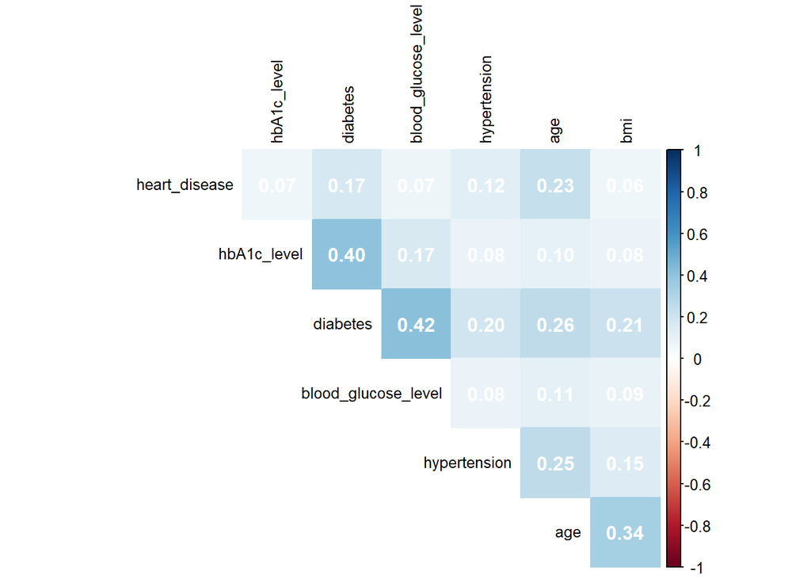

```
##                      diabetes       age        bmi hbA1c_level
## diabetes            1.0000000 0.2580228 0.21437813  0.40072354
## age                 0.2580228 1.0000000 0.33740782  0.10138734
## bmi                 0.2143781 0.3374078 1.00000000  0.08302253
## hbA1c_level         0.4007235 0.1013873 0.08302253  1.00000000
## blood_glucose_level 0.4196031 0.1106966 0.09131569  0.16683029
## hypertension        0.1978010 0.2511863 0.14767978  0.08094478
## heart_disease       0.1717108 0.2333732 0.06120341  0.06759444
##                     blood_glucose_level hypertension heart_disease
## diabetes                     0.41960311   0.19780100    0.17171077
## age                          0.11069661   0.25118631    0.23337319
## bmi                          0.09131569   0.14767978    0.06120341
## hbA1c_level                  0.16683029   0.08094478    0.06759444
## blood_glucose_level          1.00000000   0.08443119    0.07006815
## hypertension                 0.08443119   1.00000000    0.12124558
## heart_disease                0.07006815   0.12124558    1.00000000
```

Les corrélations les plus marquantes (positives) avec le diabète sont :

**blood_glucose_level → 0.42** C’est la variable la plus fortement corrélée avec le diabète. Cela confirme que les niveaux de glucose sanguin sont un indicateur clé pour détecter le diabète.

**hbA1c_level → 0.40** Une autre variable très liée au diabète, logique puisque HbA1c reflète la glycémie sur le long terme.

**age → 0.26** Les personnes âgées semblent plus susceptibles d’être diabétiques.

**hypertension → 0.20** Une légère corrélation qui suggère qu’avoir de l’hypertension peut être un facteur de risque.

**bmi → 0.21** Le surpoids (mesuré par l’IMC) est aussi un facteur notable.

**heart_disease → 0.17** Une corrélation faible, mais présente.

=> Les variables blood_glucose_level, hbA1c_level, age, BMI, et hypertension sont les facteurs les plus associés au diabète dans ce jeu de données. Les corrélations ne sont pas extrêmement fortes (aucune > 0.5), mais elles confirment bien des facteurs de risque connus du diabète.

## Analyse croisée 1 : BMI et Blood Glucose chez les personnes diabétiques

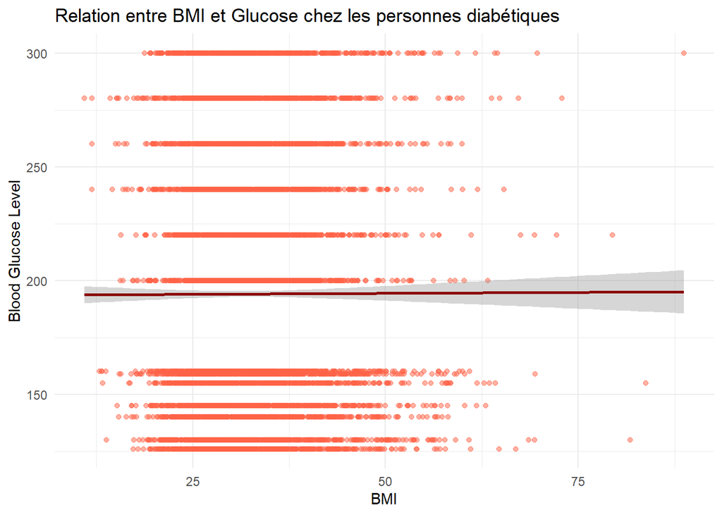

## Analyse croisée 2 : Age et HbA1c par statut diabétique

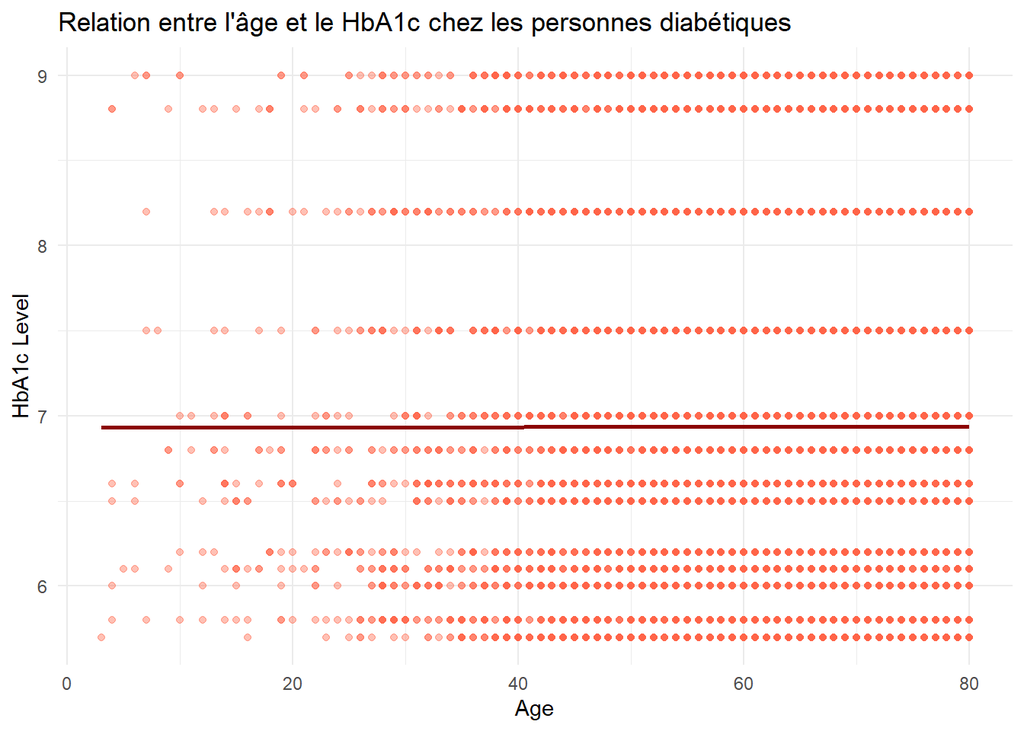

## Analyse croisée 3 : Blood Glucose et HbA1c

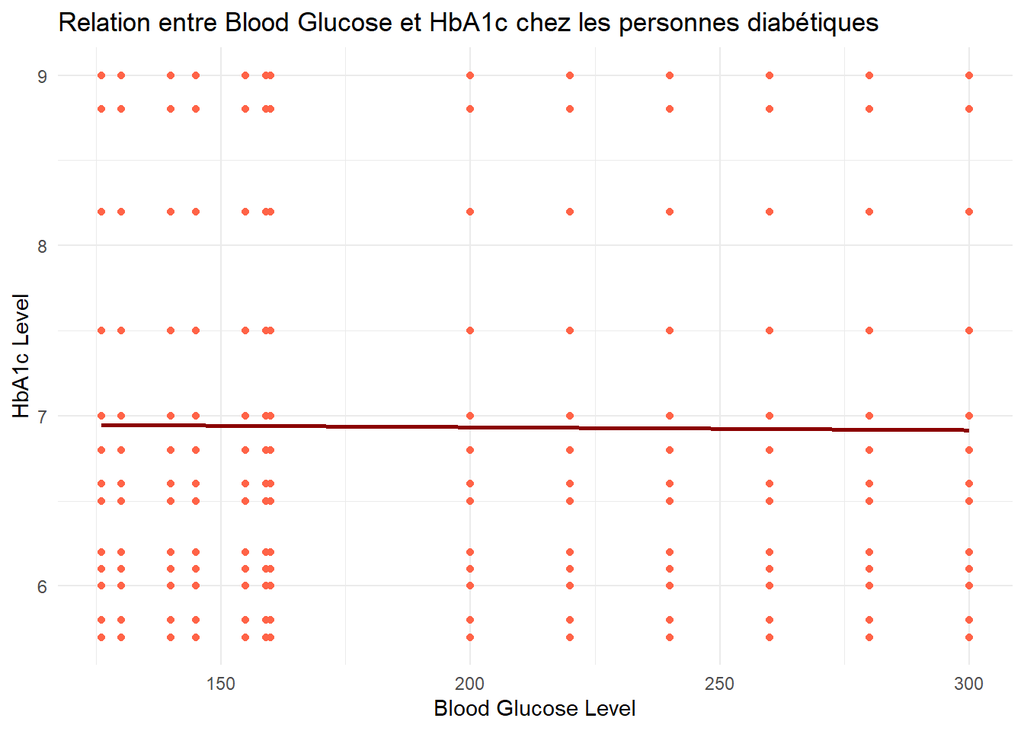

Enfin, il est à noter que les deux dernières analyses croisées réalisées n’ont pas apporté de résultats particulièrement intéressants. Elles ne semblent pas refléter de relations pertinentes.

#conclusion L’analyse globale, notamment via la matrice de corrélation, permet de mieux répondre à notre question de départ. Les facteurs les plus associés à la présence de diabète sont les suivants :

**blood_glucose_level** (corrélation de 0.42) et **hbA1c_level** (0.40), qui sont logiquement des indicateurs biologiques centraux dans le diagnostic du diabète.

Suivent ensuite l’**âge** (0.26), l’**hypertension** (0.20), le **bmi** (0.21) et la **présence de maladie cardiaque** (0.17). Bien que ces corrélations ne soient pas très élevées (aucune n’excède 0.5), elles confirment des facteurs de risque bien établis dans la littérature médicale.

Ainsi, ce jeu de données met en évidence des liens cohérents entre certaines caractéristiques cliniques et la probabilité d’être atteint de diabète.